# Small Worlds and Large Worlds

Gina Nichols

5/31/2020

These are Gina’s exercises from chapter 2 for the book “Statistical Rethinking” by Richard McElreath

# Easy, quote un-quote

### 2E1. The probability of rain on Monday?

2. Pr(rain|Monday)

### 2E2. Pr(Monday|rain)

3. prob it is monday given that it is raining

### 2E3. prob it is monday, given it is raining

1. Pr(Monday|rain)

### 2E4.

If you toss the globe once, I am not certain what your finger will land on. But, given the knowledge I do have, more often than not your finger will land on water.

# Medium

### 2M1.

Redo the example in the book first.

Define the ‘grid’, which is actually just a vector in this case. It is all the values of the parameter *p*, the *proportion of water*, we wish to evaluate the plausibility of our data for.

```r
# define grid
grid_dat <- tibble::tibble(p_grid = seq( from = 0, to = 1, length.out = 20))
grid_dat
```

```
## # A tibble: 20 x 1
##    p_grid
##     <dbl>
##  1 0
##  2 0.0526
##  3 0.105
##  4 0.158
##  5 0.211
##  6 0.263
##  7 0.316
##  8 0.368
##  9 0.421
## 10 0.474
## 11 0.526
## 12 0.579
## 13 0.632
## 14 0.684
## 15 0.737
## 16 0.789
## 17 0.842
## 18 0.895
## 19 0.947
## 20 1
```

Next:

- Define the prior belief for our data
- Find the likelihood of our data for an assumed probability value (from the grid)
- Update the prior by multiplying it by the liklihood
- Standardize the curve

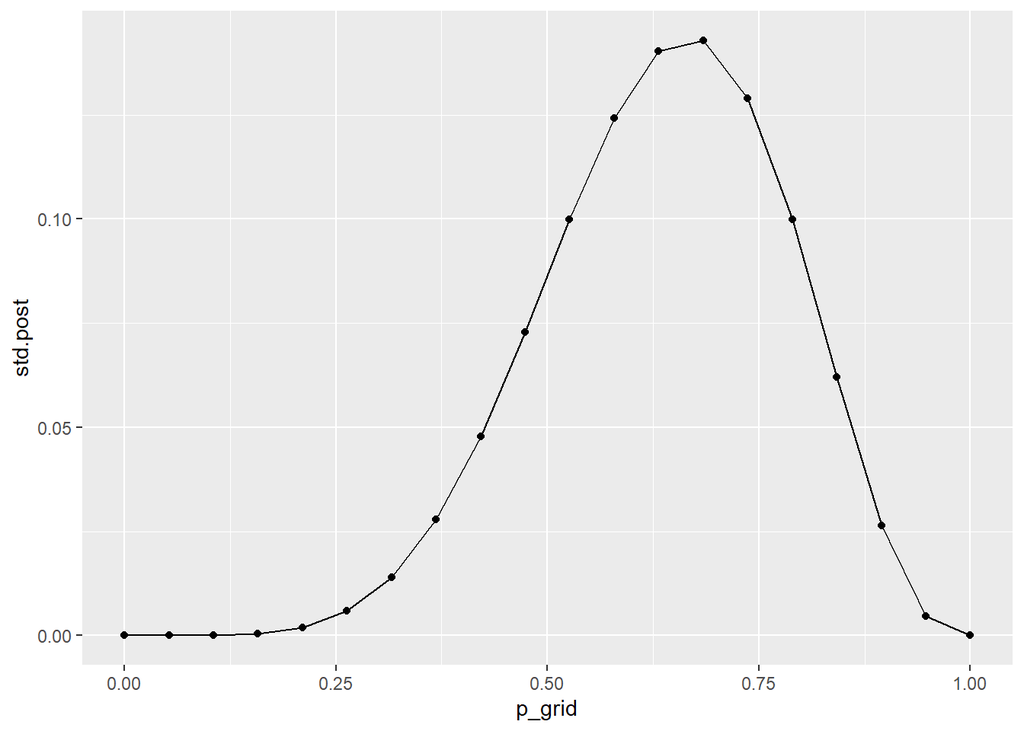

```r
grid_dat %>%
  mutate(prior = rep( 0.5, 20 ),  # The actual number doesn't matter, everything gets standardized
         likelihood = dbinom( 6, size = 9, prob = p_grid), # find likelihood for our data at a proportion of water
         unstd.post = likelihood * prior,
         std.post = unstd.post/sum(unstd.post)) %>%
  ggplot(aes(p_grid, std.post)) +
  geom_point() +
  geom_line()
```

Repeat the example for 3 different datasets:

1. W, W, W (3, 3)
2. W W W L (3, 4)
3. L W W L W W W (5, 7)

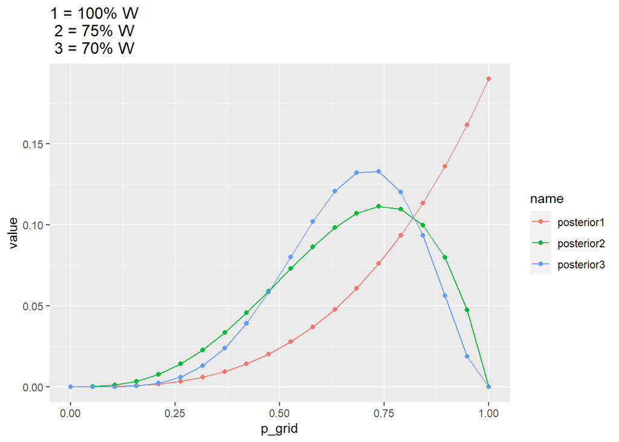

```r
grid_dat %>%
  mutate(prior = rep( 1, 20 ),
         #--first data set
         likelihood1 = dbinom( 3, size = 3, prob = p_grid),
         unstd.post1 = likelihood1 * prior,
         posterior1 = unstd.post1/sum(unstd.post1),
         #--second data set
         likelihood2 = dbinom( 3, size = 4, prob = p_grid ),
         unstd.post2 = likelihood2 * prior,
         posterior2 = unstd.post2/sum(unstd.post2),
         #--third data set
         likelihood3 = dbinom( 5, size = 7, prob = p_grid ),
         unstd.post3 = likelihood3 * prior,
         posterior3 = unstd.post3/sum(unstd.post3)) %>%
  select(p_grid, contains("posterior")) %>%
  pivot_longer(posterior1:posterior3) %>%
  ggplot(aes(p_grid, value, color = name, group = name)) +
  geom_point() +
  geom_line() +
  labs(title = "1 = 100% W\n 2 = 75% W\n 3 = 70% W")
```

### 2M2. Assume step-wise prior

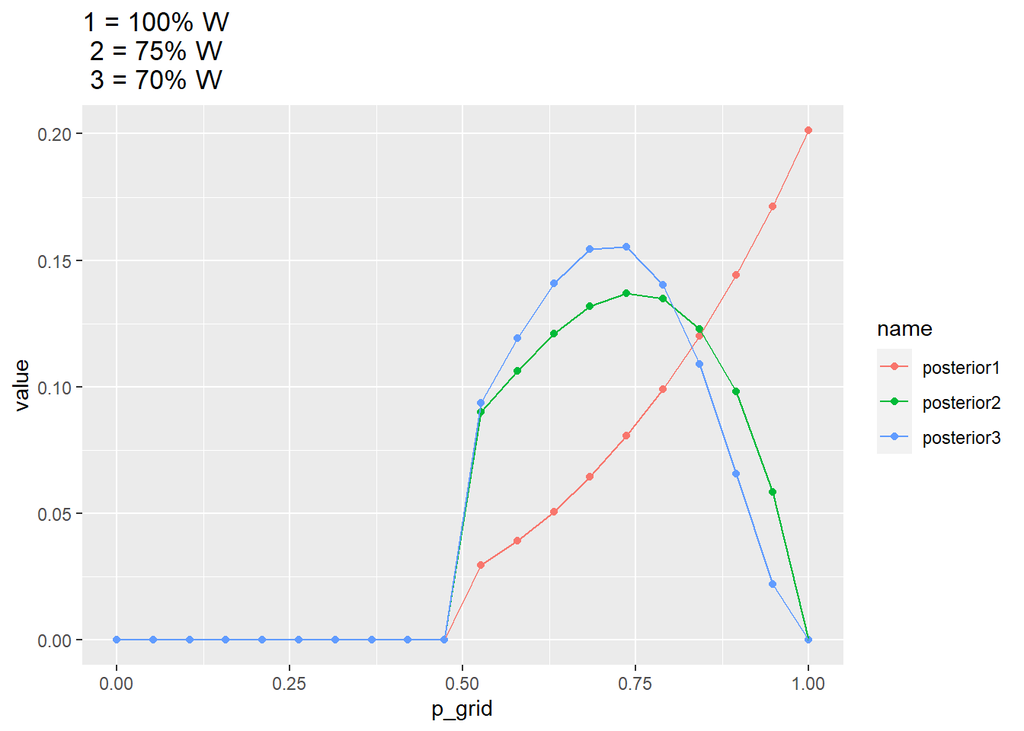

```r
grid_dat %>%
  mutate(prior = c(rep( 0, 10 ), rep( 0.5, 10)),
         #--first data set
         likelihood1 = dbinom( 3, size = 3, prob = p_grid),
         unstd.post1 = likelihood1 * prior,
         posterior1 = unstd.post1/sum(unstd.post1),
         #--second data set
         likelihood2 = dbinom( 3, size = 4, prob = p_grid ),
         unstd.post2 = likelihood2 * prior,
         posterior2 = unstd.post2/sum(unstd.post2),
         #--third data set
         likelihood3 = dbinom( 5, size = 7, prob = p_grid ),
         unstd.post3 = likelihood3 * prior,
         posterior3 = unstd.post3/sum(unstd.post3)) %>%
  select(p_grid, contains("posterior")) %>%
  pivot_longer(posterior1:posterior3) %>%
  ggplot(aes(p_grid, value, color = name, group = name)) +
  geom_point() +
  geom_line() +
  labs(title = "1 = 100% W\n 2 = 75% W\n 3 = 70% W")
```

### 2M3. Earth ball (70% water) and mars ball (0% water).

What is the probability the ball tossed was earth, given the finger landed on land?

```r
prob_earth <- 0.5
prob_land_given_earth <- 0.3
prob_land <- 130/200

prob_earth_given_land <- prob_land_given_earth * prob_earth / prob_land

prob_earth_given_land
```

```
## [1] 0.2307692
```

### 2M4. Use the counting method to determine the prob the other side of the card is black

Build the count table like the marble example. Not sure on notation (prob/plaus?)

```r
tribble(
~ conj,  ~ ways_to_get_B, ~plaus_B,  ~prob_B_when_flipped,
"W/W",       0,             "0",              0,
"W/B",       1,             "1/3",            0,
"B/B",       2,              "2/3",           1,
)
```

```
## # A tibble: 3 x 4
##   conj  ways_to_get_B plaus_B prob_B_when_flipped
##   <chr>         <dbl> <chr>                 <dbl>
## 1 W/W               0 0                         0
## 2 W/B               1 1/3                       0
## 3 B/B               2 2/3                       1
```

Multiply plaus by prob_B_when_flipped and sum: 2/3

### 2M5. What if we add another B/B card to the bag?

```r
tribble(
~ conj,  ~ ways_to_get_B, ~plaus_B,  ~prob_B_when_flipped,  ~ plausBxprobB,
"W/W",       0,             "0",              0,                  "0",
"W/B",       1,             "1/5",            0,                  "0",
"B/B",       2,              "2/5",           1,                 "2/5",
"B/B",       2,              "2/5",           1,                  "2/5"
)
```

```
## # A tibble: 4 x 5
##   conj  ways_to_get_B plaus_B prob_B_when_flipped plausBxprobB
##   <chr>         <dbl> <chr>                 <dbl> <chr>
## 1 W/W               0 0                         0 0
## 2 W/B               1 1/5                       0 0
## 3 B/B               2 2/5                       1 2/5
## 4 B/B               2 2/5                       1 2/5
```

Sum of *plausBxprobB* column: 0.8 (4/5)

### 2M6. What if black ink is heavier?

```r
tribble(
~ conj, ~bag_wgt, ~ ways_to_get_B_count,  ~new_count,  ~plaus_B,   ~prob_B_flip,   ~plauBxprobB,
"W/W",       3,        0,                   0,            "-",          0,        "0",
"W/B",       2,        1,                   2,            "2/4",        0,        "0",
"B/B",       1,        2,                   2,            "2/4",        1,        "2/4",
)
```

```
## # A tibble: 3 x 7
##   conj  bag_wgt ways_to_get_B_count new_count plaus_B prob_B_flip plauBxprobB
##   <chr>   <dbl>               <dbl>     <dbl> <chr>         <dbl> <chr>
## 1 W/W         3                   0         0 -                 0 0
## 2 W/B         2                   1         2 2/4               0 0
## 3 B/B         1                   2         2 2/4               1 2/4
```

### 2M7. New information, white face

```r
tribble(
~ conjectured_first_card, ~ ways_to_get_B_then_white_count,  ~plaus,  ~prob_B_flip,    ~plauBxprobB,
     "W/W",                              0,                   "0",            0,              "0",
     "W/B",                              2,                   "2/8",         0,             "0",
     "B/B",                              6,                   "6/8",        1,             "6/8"
)
```

```
## # A tibble: 3 x 5
##   conjectured_first_ca~ ways_to_get_B_then_white_~ plaus prob_B_flip plauBxprobB
##   <chr>                                      <dbl> <chr>       <dbl> <chr>
## 1 W/W                                            0 0               0 0
## 2 W/B                                            2 2/8             0 0
## 3 B/B                                            6 6/8             1 6/8
```

0.75

# Hard

#### 2H1. What is the probability next set is twins?

Try count method.

```r
tribble(
~ conjectured_species, ~ ways_to_get_twins,  ~plaus_twins,  ~prob_twins_again,    ~plauxprob,
     "A",                         10,             "1/3",            0.1,              "1/30",
     "B",                         20,             "2/3",            0.2,              "2/30"
)
```

```
## # A tibble: 2 x 5
##   conjectured_species ways_to_get_twins plaus_twins prob_twins_again plauxprob
##   <chr>                           <dbl> <chr>                  <dbl> <chr>
## 1 A                                  10 1/3                      0.1 1/30
## 2 B                                  20 2/3                      0.2 2/30
```

So total probability of having twins again is 3/30, or 0.1.

### 2H2. What is probability she is species A, given our data?

$prob(A|data) = \frac{prob(data|A)prob(A)}{prob(data)}$

$prob(A) = 0.5$ This one should probably be a distribution?

$prob(data) = 0.1 + 0.2$ Total probability of twins

$prob(data|A) = 0.1$ Assume she is A, this is how likely our data (seeing twins) is

So $prob(A|data) = \frac{0.1 * 0.5}{0.3}$. 16.6666667% probability it’s species A.

### 2H3. Say mama panda has another pregnancy, this time it’s a single infant. Find posterior prob she is species A.

I need help.